# 06 Analyzing Text

# 4 Sentiment Analysis

We can also analyze text for it’s sentiment, which requires assigning values to each word based on what sentiment they express (positive or negative; happy, sad, or angry; etc). There are several lexicons available to use that have already done such sorting/assigning for us. Of course you might want to look into lexicons that are more specific for certain domains or types of texts, or that identify key sentiments. You might use more than one lexicon to ensure consistency of patterns. It’s also possible to build your own (or validate one) by assigning words yourself or crowdsourcing the task. What lexicon you choose should be motivated by your research questions and carefully chosen!

We’ll use the bing lexicon where words are categorized in a binary positive - negative.

```r
# you might need to install a necessary package and agree to download when using

bing<-get_sentiments("bing")
bing

# now we join this with our tidy_captions dataframe

tidy_captions_sent <- left_join(tidy_captions, bing, by="word")

head(tidy_captions_sent)

# let's filter out all the words that were unassigned

words_sent<-tidy_captions_sent %>%
  filter(!sentiment=="NA")

# we have 991 words with an assigned sentiment

words_sent
```

Are Biden and Harris mostly positive or negative with their instagram captions?

```r
words_sent%>%
  count(sentiment)%>%
  mutate(total=sum(n), freq =n/total)
```

What are the most common words for each sentiment for both Biden and Harris?

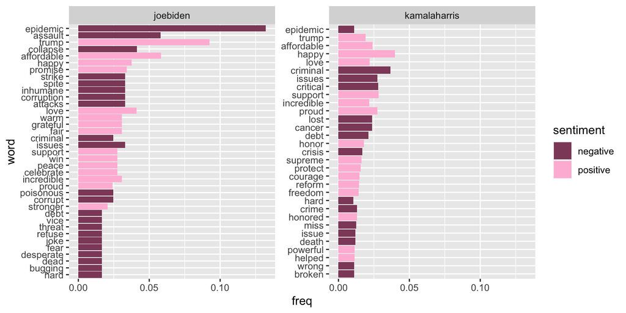

```r
words_sent%>%
  group_by(username, sentiment) %>%
  mutate(total=sum(n), freq=n/total) %>%
  top_n(15, freq)%>%
  ungroup() %>%
  mutate(word=reorder(word, freq)) %>%
  ggplot(aes(y=word, x=freq, fill=sentiment))+
  geom_col()+
  facet_wrap(~username, scales="free_y")+
  scale_fill_manual(values=c("#8e4b69","#ffbbd9"))
```

We can go look for sentiment patterns over time, or maybe see if words of shared sentiments cluter over time. Here’s how I would visualize sentiment change over time:

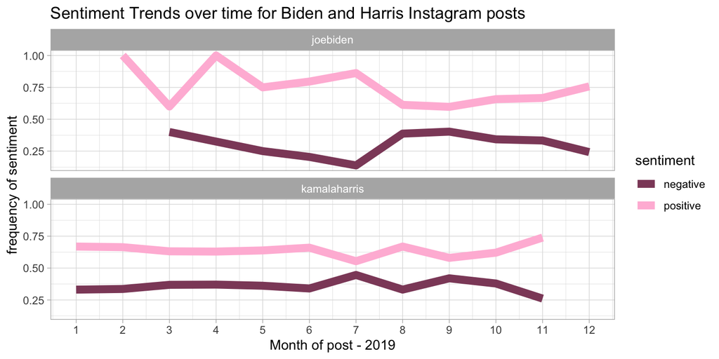

```r
tidy_captions_step2 %>%
  inner_join(bing) %>%
  filter(!sentiment=="NA", !pubyear=="2020") %>%
  group_by(username, pubmonth)%>%
  count(sentiment) %>%
  mutate(total=sum(n), freq=n/total)%>%
  ggplot(aes(x=pubmonth, y=freq, color=sentiment))+
  geom_line(size=3)+
  facet_wrap(~username, nrow=2)+
  scale_color_manual(values=c("#8e4b69","#ffbbd9"))+
  scale_x_continuous(breaks=c(1:12))+
  ylab("frequency of sentiment")+
  xlab("Month of post - 2019")+
  ggtitle("Sentiment Trends over time for Biden and Harris Instagram posts ")+
  theme_light()
```

# 5 N-grams

So far we’ve looked at singular words, but often we might be interested in the relationship between words. We can easily use the same unnest_tokens function to identiy n-grams or sets of n numbers of consecutive words. Here’s an example to identify bi-grams (2 consecutive word pairs)

```r
caption_bigrams <- captions %>%
  unnest_tokens(bigram, description, token="ngrams", n=2)

head(caption_bigrams)

# let's see what are the most common
count<-caption_bigrams %>%
  count(bigram, sort=TRUE)

head(count, 20)

# lots of stop words are included which aren't that interesting for our analysis, we can remove them by separating and filtering the bigrams:

# first, separate
bigrams_sep <- caption_bigrams %>%
  separate(bigram, c("w1", "w2"), sep=" ")

# second, filter (this should look familiar)

filtered_bigrams <- bigrams_sep %>%
  filter(!w1 %in% stop_words$word) %>%
  filter(!w2 %in% stop_words$word)

# count the filtered bigrams

count_bigrams <- filtered_bigrams %>%
  count(w1, w2, sort=TRUE)
count_bigrams

# we can also unite them back together and then proceed to analyze as we would with the singular words
bigrams <- filtered_bigrams %>%
  unite(bigram, w1, w2, sep= " ")

count2<-bigrams %>%
  count(bigram, sort=TRUE)

head(count2, n=20)
```

## 5.1 On your own:

1. What words get the most likes for both Biden and Harris? Identity and visualize the top 10 re-occuring words that get the highest average number of likes for both Biden and Harris.

TIP: Make a dataframe that includes the like count for each post associated with each instance of the word, and filter out any words that only appear once. Next, group by username and word and average the likecount to get an average like for each word – instead of n per word you should have a variable like ave_like and each word-username combo is one line. Identify the top 10 most liked words for both Biden and Harris and use geom_col to plot them (you’ll also want to use facet_wrap). TIP 2: Review Ch. 7.5 of the Tidy Text Mining Book (https://www.tidytextmining.com/twitter.html) for an example of this applied to Twitter Data.

2. annotate each line of the script to make the last plot (change in sentiment over time). If you need help, try running it line by line.

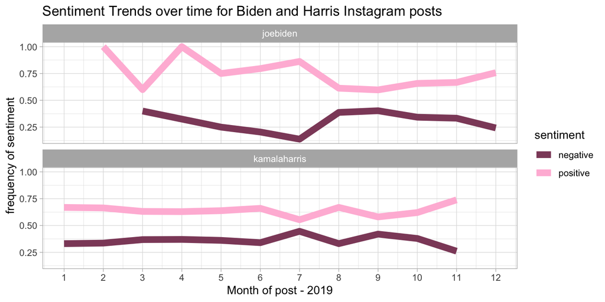

```r
tidy_captions_step2 %>% # annotate here
  inner_join(bing) %>% # what does this line
  filter(!sentiment=="NA", !pubyear=="2020") %>%
  group_by(username, pubmonth)%>%
  count(sentiment) %>%
  mutate(total=sum(n), freq=n/total)%>%
  ggplot(aes(x=pubmonth, y=freq, color=sentiment))+
  geom_line(size=3)+
  facet_wrap(~username, nrow=2)+
  scale_color_manual(values=c("#8e4b69","#ffbbd9"))+
  scale_x_continuous(breaks=c(1:12))+
  ylab("frequency of sentiment")+
  xlab("Month of post - 2019")+
  ggtitle("Sentiment Trends over time for Biden and Harris Instagram posts ")+
  theme_light()
```